# Fast starts and blow-ups at the UTMB

Whether going out ahead of your rating leads to dropping out depends on the runner — and the direction reverses as ability rises. Measured continuously on 2,382 starters, then re-tested on the 2024 and 2025 editions.

Author

Alexis Konarski

Published

September 7, 2026

Trail-running lore holds that starting too fast makes runners blow up. The 2026 UTMB — 2,382 starters, each with a pre-race rating and a timestamp at every checkpoint — lets us test it, and the 2024 and 2025 editions let us check whether the answer repeats.

**How the question is posed.** A fast early split often just means a strong runner, so we measure early pace *relative to ability*: each runner’s elapsed time at a checkpoint, with the effect of their **UTMB Index** removed by a flexible (spline) fit over the whole field. What is left is **overpace** — positive means arriving faster than the rating predicts.

The primary reading is taken at the **first timing point, Col de Voza (14.4 km)**: it is the closest thing the race has to a measurement of intent off the gun, before anyone has had time to correct course. Les Contamines (32.4 km) is carried alongside as a check.

# Who drops out, and why

The four bands fail at different rates and for different reasons. Above an index of 600, time cut-offs essentially disappear.

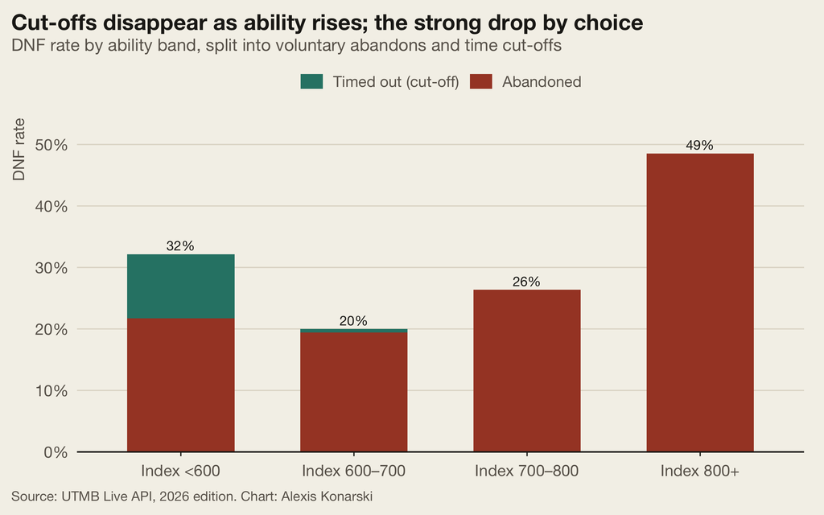

Figure 1: Bars stacked into the two DNF causes; the number above each is the band’s total DNF rate.

The elite band (800+) has the highest DNF rate at 49% — and every one of those 66 non-finishers walked away by choice, not because the clock caught them. In the lowest band, by contrast, 32% of non-finishers were timed out.

Where runners stop is **not** the same across bands (Kruskal-Wallis p < 0.001) — and the pattern is not the obvious one. It is U-shaped: the weakest and the strongest both quit early, around Courmayeur, while the two middle bands push on well past it.

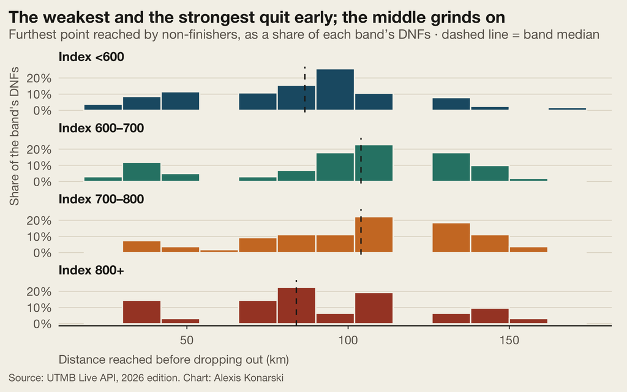

Figure 2: Distribution of the furthest point reached by each band’s non-finishers, as a share of that band’s DNFs so the bands are directly comparable. Dashed line = band median.

Median distance reached: **87 km** for the sub-600 band and **84 km** for the elite, against **104 km** and **104 km** for the two middle bands. The share quitting before Courmayeur runs 35% / 23% / 22% / 32%. The two ends of the field arrive at the same exit for opposite reasons: the weakest are squeezed out by the cut-offs, the strongest step off once the result they came for is gone.

# A fast start: protective for the weak, a hazard for the strong

Sorting each band into thirds by early pace shows the effect of a fast start reversing as ability climbs. For weak runners it is the single best sign in the data; for the 700–800 band it looks like a liability — though, as the cross-edition check below shows, that half of the picture is the shakier one.

**Col de Voza · 14.4 km (primary)**

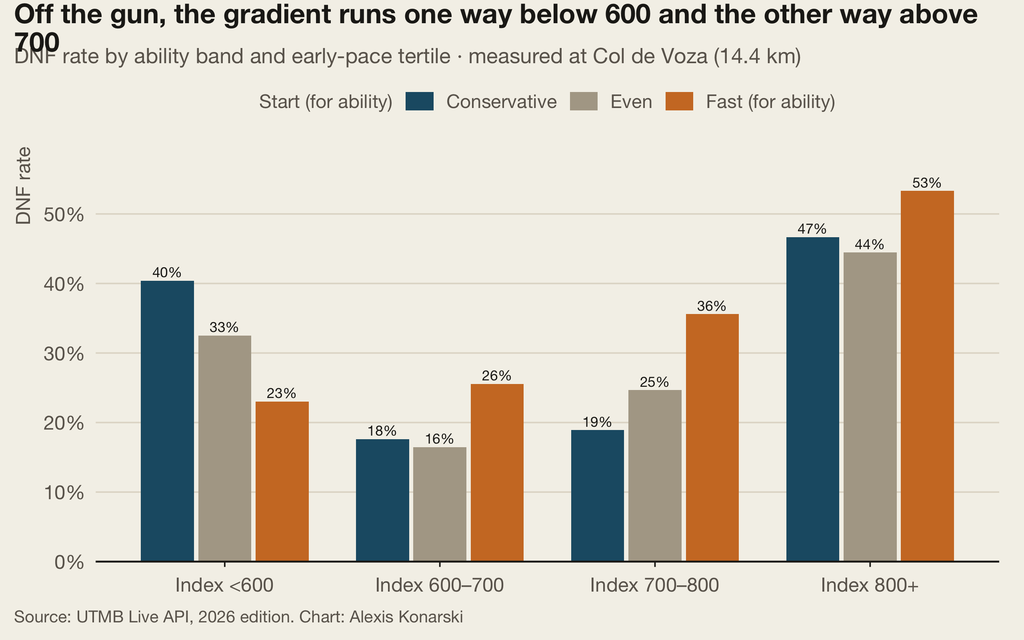

Figure 3: DNF rate by ability band and early-pace tertile, measured off the gun at Col de Voza. Within each band, runners are split into equal thirds by overpace.

**Les Contamines · 32.4 km (check)**

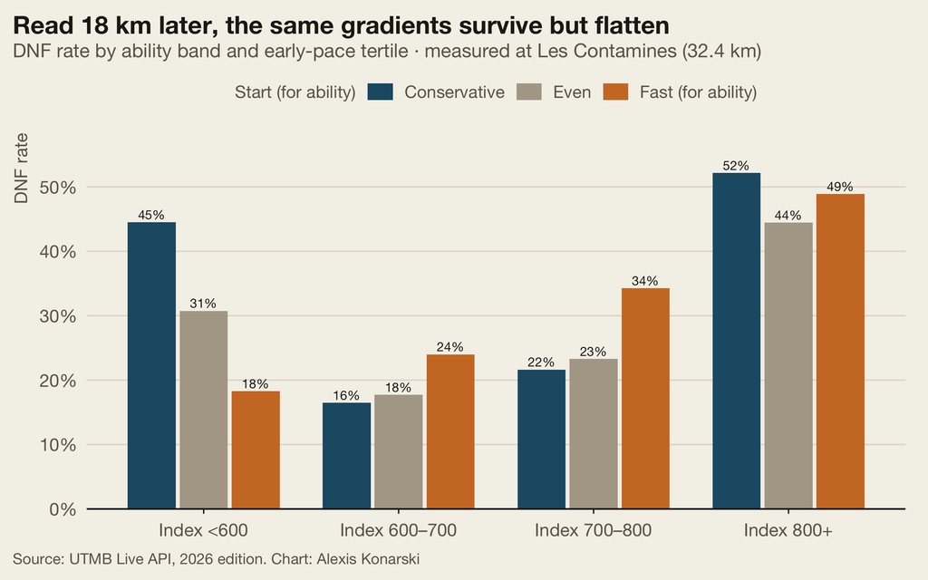

Figure 4: The same split, read 18 km later at Les Contamines. The gradients survive but flatten, as runners who set off too hard rein it in.

Reading across the bands at Col de Voza:

# The reversal, measured properly

Cutting the field into four bands is convenient but arbitrary — the boundaries at 600, 700 and 800 are round numbers, and testing each band separately throws away most of the data at each step. The claim being made is really a single one: **the effect of a fast start changes sign as ability rises.** That can be fitted, and tested, in one model.

The answer is unambiguous: allowing the pacing effect to vary with ability improves the fit enormously (χ² = 46.8 on 4 df, p < 0.001). A fast start does not have *an* effect on dropping out — it has opposite effects at opposite ends of the field, and one number for the whole race is meaningless.

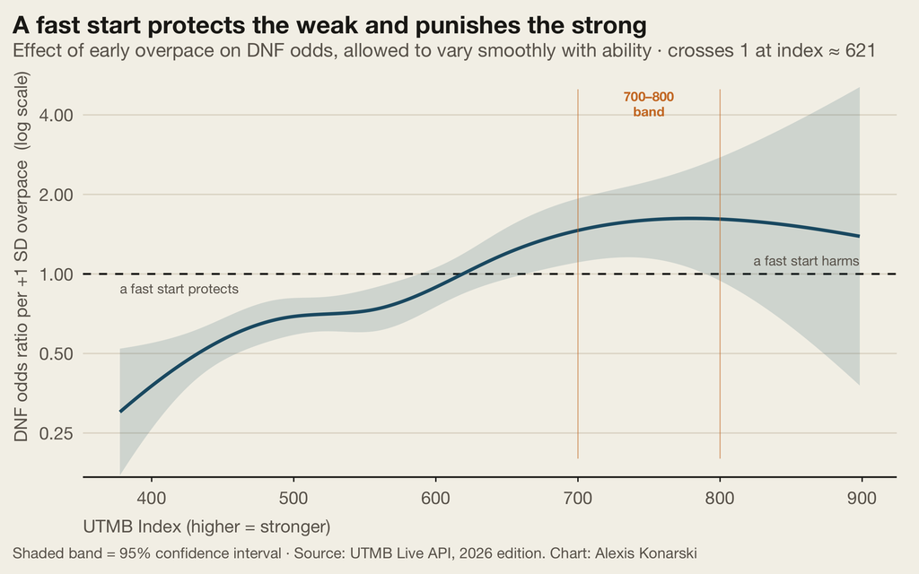

Figure 5: DNF odds ratio per +1 SD of overpace at Col de Voza, as a continuous function of the UTMB Index, with a 95% band. Above 1 = a fast start raises DNF risk; below 1 = it lowers it.

The curve crosses 1 at an index of about **621**. Below **587** a fast start is *significantly protective*; from **665** upward it is *significantly harmful*. In the 700–800 band the odds ratio is around **1.60** per standard deviation (95% CI 1.15–2.24). Above 850 the band opens out and the data stops saying anything useful — there are only 136 runners up there, which is the honest reason the elite band looked “flat” in the bar chart.

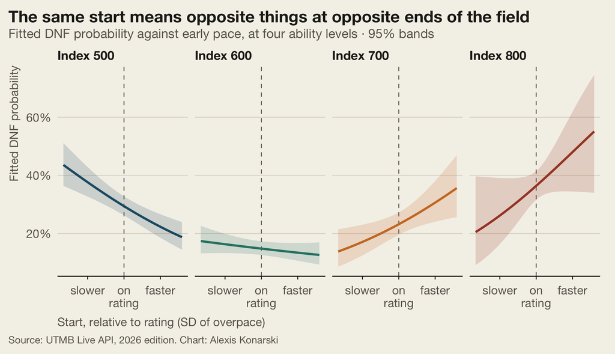

Figure 6: Fitted DNF probability against how hard a runner set off, at four ability levels. The lines fan the opposite way at the two ends of the field.

Read left to right, the slope of those four lines simply turns over: at an index of 500 setting off hard is associated with a **lower** chance of dropping out, by 700 and 800 with a **higher** one, and 600 is roughly the pivot.

# Does it repeat? 2024 and 2025

A single edition, and a result that turns on one slice of the field, invites the obvious worry: is this the shape of a real effect, or of one year’s noise? The 2024 and 2025 editions are an independent test — essentially the same course, different weather, largely different runners. Two separate things are worth asking. Does the **reversal** repeat? And does the **penalty on strong runners** specifically repeat?

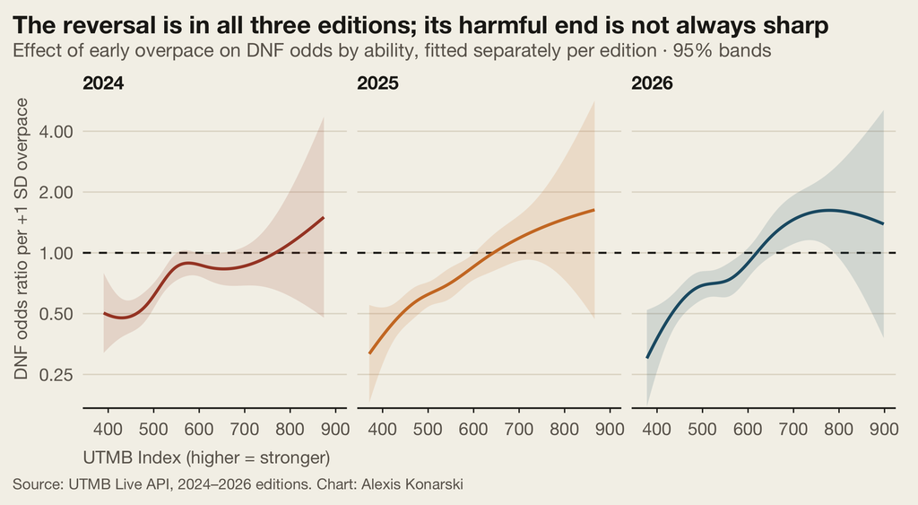

Figure 7: The same model fitted separately to each edition: DNF odds ratio per +1 SD of early overpace, against ability. All three curves slope the same way — protective on the left, harmful on the right.

Table 1: Each edition fitted separately. ‘Protective below’ and ‘harmful above’ are the index values at which the 95% band clears 1 on each side; ‘—’ means it never does.

[output not shown]

**The reversal itself replicates decisively.** In every edition, allowing the pacing effect to vary with ability beats holding it constant — p < 0.001 in 2024, p < 0.001 in 2025, p < 0.001 in 2026. And the protective end replicates with it: in all three years a fast start *significantly lowers* DNF risk for runners below an index of roughly 587–650. That half of the finding is about as solid as a single race series can make it.

**The half that matches the folklore is weaker than the 2026 data alone suggests.** The three curves all slope upward and all sit above 1 at the top end, but only 2026 has a stretch where the confidence band clears 1 on the harmful side. Read on the 700–800 band alone:

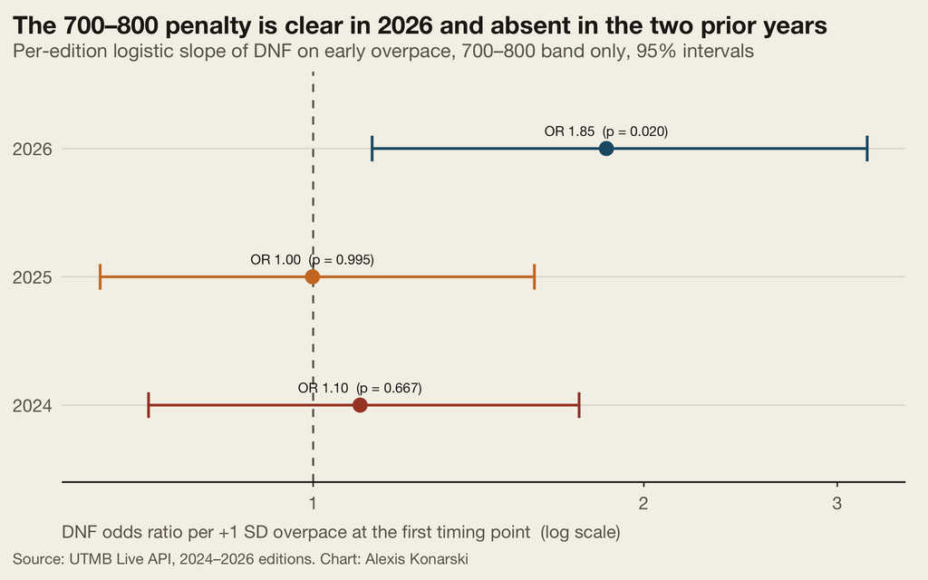

Note also that 2024 and 2025 were harder races at that level: the 700–800 band lost 34% and 39% of its runners against 26% in 2026. When a third of a band is going out whatever it does, there is less room for a pacing choice to matter — a plausible reason the effect is easiest to see in the kindest of the three years, and a reason not to read its absence in 2024–25 as a flat contradiction.

# Is it the pacing, or was the fast starter already in trouble?

The obvious alternative explanation is reverse causation of a particular kind: a runner already having a bad day might show up as *slow*-for-ability at 14 km, making conservative starts look worse than they are. Or the reverse — the “fast” starters might simply be the ones who were going to blow up anyway, visible early.

One way to separate them is to ask *when* the fast starters drop. If a hot start is genuinely spending a resource, the cost should fall due later, out on the course — not in the first few hours. The test below is run on the 2026 700–800 band, i.e. on the one edition and slice where the harmful effect is clearly present at all.

Restricting to the 209 runners in the 700–800 band who **reached Courmayeur (81 km)** — that is, throwing away everyone who cracked early — a hot start at 14 km still predicts dropping out later: OR **2.00 (95% CI 1.16–3.70)** per standard deviation, against **1.85 (95% CI 1.13–3.19)** across the whole band. The penalty is not an artefact of runners who were already failing at the first timing point; it is still there among those who got half way round.

This does not settle causation — nothing here is randomised, and a slow-for-ability start can itself be an early symptom rather than a choice. But it does rule out the simplest version of the objection.

# Summary

- **Index < 600 (1496 runners, 32% DNF).** A faster start lowers the DNF rate at every step (40% → 23%); it signals an under-rated runner and banks cut-off margin. **This replicates in all three editions.**
- **Index 600–700 (530, 20% DNF).** The crossover zone — no clear effect in either direction.
- **Index 700–800 (220, 26% DNF).** In 2026 a fast start clearly raises DNF risk (OR 1.85), and the effect survives dropping everyone who cracked before Courmayeur. **But it does not show up in 2024 (OR 1.10) or 2025 (OR 1.00)**, so treat the size of it as a 2026 result, not a law.
- **Index 800+ (136, 49% DNF).** Highest failure rate, all voluntary abandons. Too few runners to say anything about pacing.

Two findings, of very different strength.

The **robust** one is that a fast start is *not* generally dangerous — for most of the field it is a good sign. Across three editions and roughly 7,000 starters, going out ahead of your rating significantly *lowers* the odds of dropping out for anyone rated below about 600, which is the majority of the race. The blanket version of the folklore is simply wrong, and it is wrong for most of the people who repeat it.

The **suggestive** one is the half that matches the lore. The effect does reverse as ability rises — that reversal is highly significant in each edition separately — and at the top end the odds ratio sits above 1 in all three years. But it is only sharp enough to call in 2026, in the 700–800 band. On the evidence here a strong runner going out hard is a reasonable thing to worry about, and not something to state as established.

# Method and limitations

- **Data.** `R/scrape_all_runners.R` (2026) and `R/scrape_history.R` (2024, 2025) → `runners_all_utmb*.csv`, `passings_all_utmb*.csv`. Of 2,467 bibs returned for 2026, 2,382 are used: starters with both a recorded outcome (finisher or DNF) and a UTMB Index. The remainder are non-starters, other statuses, or runners with no index. Per-runner derived values in `data/processed/pacing_blowup_utmb.csv`.
- **Checkpoints across editions.** The `pointId` scheme is *not* shared between editions, and no endpoint maps a pointId to a place. `derive_checkpoints()` in `R/checkpoints.R` rebuilds each edition’s distance table from the passings themselves (section speed × section split, median across runners); it reproduces the hand-read 2026 table to within 0.1 km. Anchors are then picked by distance, so the same points on the course are compared across years.
- **Overpace** = −residual of elapsed time at the checkpoint on the UTMB Index, fitted with a natural spline (4 df) over every runner reaching that checkpoint. The spline matters: a straight-line fit leaves real index structure in the residual (within the 800+ band the linear residual still correlates −0.48 with the index; with the spline it is −0.03), which would make “fast start” partly a proxy for “lower-rated within the band”.
- **The primary reading is Col de Voza (14.4 km)**, the first timing point, chosen because it is the earliest available measure of intent. Les Contamines is reported alongside as a check, not as a competing test.
- **The headline test** is a single likelihood-ratio test of whether the overpace effect varies with ability, on the whole field at once (χ² = 46.8, 4 df). The per-band models are descriptive; with only 220 runners in the 700–800 band, no single band-level test carries much weight on its own, which is why the cross-edition replication is the load-bearing evidence.
- **Distance at DNF** uses `last_point_id`, the last checkpoint at which a runner was *timed*. A runner who is seen but not timed is attributed to the previous point, so these distances are mildly conservative.
- **Replication.** 2024 and 2025 are re-analysed with the identical pipeline. The first timing point sits at 13.2 km in 2024 and 14.6 km in 2025 against 14.4 km in 2026 — close but not identical, which is harmless here because overpace is residualised within each edition, but it does mean the three “off the gun” readings are not taken at exactly the same spot.
- **What replicated and what did not.** The reversal, and the protective effect on weaker runners, reproduce in all three editions. The magnitude of the penalty in the 700–800 band does not: it is clear in 2026 and absent in 2024–25. The article reports both.
- **Associational.** No randomisation of pacing. Reverse causation is probed (above) but not eliminated. The Index is a noisy ability proxy, so some genuine ability signal survives inside “overpace” even after the spline.